# Project Case Study 2 Question 1

1.Your Friend has developed the Product and he wants to establish the product startup and he is searching for a perfect location where getting the investment has a high chance. But due to its financial restriction, he can choose only between three locations - Bangalore, Mumbai, and NCR. As a friend, you want to help your friend deciding the location. NCR include Gurgaon, Noida and New Delhi. Find the location where the most number of funding is done. That means, find the location where startups has received funding maximum number of times. Plot the bar graph between location and number of funding. Take city name "Delhi" as "New Delhi". Check the case-sensitiveness of cities also. That means, at some place instead of "Bangalore", "bangalore" is given. Take city name as "Bangalore". For few startups multiple locations are given, one Indian and one Foreign. Consider the startup if any one of the city lies in given locations.

```
NCR 709
Bangalore 637
Mumbai 449
```

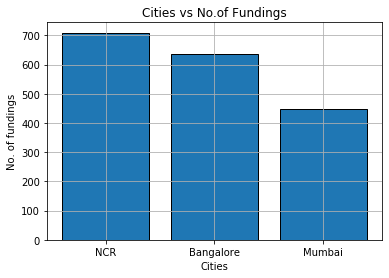

```python
import matplotlib.pyplot as plt
import numpy as np
import pandas as pd
d = pd.read_csv('C:/Users/sowndariya/Desktop/CNN/startup_funding.csv')
#location with most number of fundings
# removing row's having nan's in CityLocation
d.CityLocation.dropna(inplace=True)
#getting Bangalore, Mumbai, and NCR cities
#there are many bangalore there, inorder to get that and to get the delhi, noida, gurgaon together as NCR.Using the following fuction
def checkcity(city):
    cities=city.split('/')
    for i in cities:
        if (i.strip() == 'Bangalore') or (i.strip() == 'bangalore'):
            return 'Bangalore'
        elif (i.strip() == 'Mumbai'):
            return 'Mumbai'
        elif (i.strip() == 'Delhi') or (i.strip() == 'Gurgaon') or (i.strip() == 'Noida') or (i.strip() == 'New Delhi'):
            return 'NCR'
    else:
        return city
d.CityLocation=d.CityLocation.apply(checkcity)
#getting three cities and their count alone
d.CityLocation=d.CityLocation[(d.CityLocation=='Bangalore')|(d.CityLocation=='Mumbai')|(d.CityLocation=='NCR')]
citycounts=d.CityLocation.value_counts()[:3]
city_names=citycounts.index
no_of_fundings=citycounts.values
for i in range(len(city_names)):
    print(city_names[i],no_of_fundings[i])
#plotting graph
plt.bar(city_names,no_of_fundings,edgecolor='black')
plt.xlabel('Cities')
plt.ylabel('No. of fundings')
plt.title('Cities vs No.of Fundings')
plt.grid()
plt.show()
# I suggest my friend to choose NCR, where the number of funding is highest and it gets 709 times.
```